# Basic usage of NIMBLE

UW 2020 short course

NIMBLE Development Team

# Running example: An occupancy model

- AHM = [Applied Hierarchical Modeling in Ecology, Vol. I](https://www.mbr-pwrc.usgs.gov/pubanalysis/keryroylebook/) by Marc Kéry and J. Andrew Royle. 2015. Elsevier.
- Most AHM examples have been converted to NIMBLE: https://github.com/nimble-dev/AHMnimble
- Thanks to Marc Kéry, Andy Royle, and Mike Meredith for permission to post modified versions of their code on GitHub.
- Occupancy example from section 10.4:
  - Simulated data
  - `M` sites.
  - Each site is visited `J` times.
  - `y[i, j]` is detection (`1`) or non-detection (`0`) for visit `j` to site `i`.
  - Explanatory variables:
    - `vegHt` = Vegetation height: logistic effect on occupancy probability
    - `wind` = Wind speed: logistic effect on detection probability

# Occupancy example: Write the model code **in R**

- Slightly modified from AHM.
- Derived quantities are removed.

```r
library(nimble)
occ_code <- nimbleCode({
  # Priors
  mean.p ~ dunif(0, 1)         # Detection intercept on prob. scale
  alpha0 <- logit(mean.p)      # Detection intercept
  alpha1 ~ dunif(-20, 20)      # Detection slope on wind
  mean.psi ~ dunif(0, 1)       # Occupancy intercept on prob. scale
  beta0 <- logit(mean.psi)     # Occupancy intercept
  beta1 ~ dunif(-20, 20)       # Occupancy slope on vegHt

  # Likelihood
  for (i in 1:M) {
    # True state model for the partially observed true state
    z[i] ~ dbern(psi[i])      # True occupancy z at site i
    logit(psi[i]) <- beta0 + beta1 * vegHt[i]
    for (j in 1:J) {
      # Observation model for the actual observations
      y[i,j] ~ dbern(p.eff[i,j])    # Detection-nondetection at i and j
      p.eff[i,j] <- z[i] * p[i,j]   # 'straw man' for WinBUGS
      logit(p[i,j]) <- alpha0 + alpha1 * wind[i,j]
    }
  }
  # Derived quantities are removed.
})
```

# Occupancy example: Simulate data

(This code is modified from AHM.)

```r
DO_PLOT <- TRUE
if(!exists("DO_PLOT"))
  DO_PLOT <- FALSE

# Choose sample sizes and prepare obs. data array y
set.seed(1)                   # So we all get same data set
M <- 100                      # Number of sites
J <- 3                        # Number of presence/absence measurements
y <- matrix(NA, nrow = M, ncol = J) # to contain the obs. data

# Create a covariate called vegHt
vegHt <- sort(runif(M, -1, 1)) # sort for graphical convenience

# Choose parameter values for occupancy model and compute occupancy
beta0 <- 0                    # Logit-scale intercept
beta1 <- 3                    # Logit-scale slope for vegHt
psi <- plogis(beta0 + beta1 * vegHt) # Occupancy probability
# plot(vegHt, psi, ylim = c(0,1), type = "l", lwd = 3) # Plot psi relationship

# Now visit each site and observe presence/absence perfectly
z <- rbinom(M, 1, psi)        # True presence/absence

# Look at data so far
table(z)
```

```
## z
##  0  1
## 49 51
```

```r
# Plot the true system state
if(DO_PLOT) {
  par(mfrow = c(1, 2), mar = c(5,5,2,2), cex.axis = 1.5, cex.lab = 1.5)
  plot(vegHt, z, xlab="Vegetation height", ylab="True presence/absence (z)",
              frame = F, cex = 1.5)
  plot(function(x) plogis(beta0 + beta1*x), -1, 1, add=T, lwd=3, col = "red")
}

# Create a covariate called wind
wind <- array(runif(M * J, -1, 1), dim = c(M, J))

# Choose parameter values for measurement error model and compute detectability
alpha0 <- -2                        # Logit-scale intercept
alpha1 <- -3                        # Logit-scale slope for wind
p <- plogis(alpha0 + alpha1 * wind) # Detection probability
# plot(p ~ wind, ylim = c(0,1))     # Look at relationship

# Take J = 3 presence/absence measurements at each site
for(j in 1:J) {
  y[,j] <- rbinom(M, z, p[,j])
}
sum(apply(y, 1, max))               # Number of sites with observed presences
```

```
## [1] 32
```

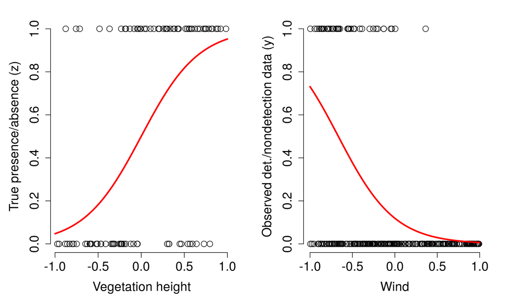

```r
# Plot observed data and true effect of wind on detection probability
if(DO_PLOT) {
  plot(wind, y, xlab="Wind", ylab="Observed det./nondetection data (y)",
             frame = F, cex = 1.5)
  plot(function(x) plogis(alpha0 + alpha1*x), -1, 1, add=T, lwd=3, col = "red")
}
```

```r
# Look at the data: occupancy, true presence/absence (z), and measurements (y)
cbind(psi=round(psi,2), z=z, y1=y[,1], y2=y[,2], y3=y[,3])
```

```
##         psi z y1 y2 y3
##   [1,] 0.05 0  0  0  0
##   [2,] 0.05 0  0  0  0
##   [3,] 0.07 0  0  0  0
##   [4,] 0.07 1  0  0  0
##   [5,] 0.07 0  0  0  0
##   [6,] 0.08 0  0  0  0
##   [7,] 0.08 0  0  0  0
##   [8,] 0.09 0  0  0  0
##   [9,] 0.09 1  1  1  0
##  [10,] 0.10 0  0  0  0
##  [11,] 0.11 1  0  0  0
##  [12,] 0.13 0  0  0  0
##  [13,] 0.13 0  0  0  0
##  [14,] 0.14 0  0  0  0
```

[output cut: 86 more lines]

```r
# Bundle and summarize data set
str( occupancy_data <- list(y = y,
                            vegHt = vegHt,
                            wind = wind,
                            M = nrow(y),
                            J = ncol(y),
                            XvegHt = seq(-1, 1, length.out=100),
                            Xwind = seq(-1, 1, length.out=100)) )
```

```
## List of 7
##  $ y     : int [1:100, 1:3] 0 0 0 0 0 0 0 0 1 0 ...
##  $ vegHt : num [1:100] -0.973 -0.953 -0.882 -0.876 -0.859 ...
##  $ wind  : num [1:100, 1:3] -0.465 -0.5627 0.0336 -0.4621 -0.6377 ...
##  $ M     : int 100
##  $ J     : int 3
##  $ XvegHt: num [1:100] -1 -0.98 -0.96 -0.939 -0.919 ...
##  $ Xwind : num [1:100] -1 -0.98 -0.96 -0.939 -0.919 ...
```

```r
# Initial values: Best to give for same quantities as priors given.
zst <- apply(y, 1, max)        # Avoid data/model/inits conflict
occupancy_inits <- function(){
  list(z = zst,
       mean.p = runif(1),
       alpha1 = runif(1),
       mean.psi = runif(1),
       beta1 = runif(1))
}

# If running multiple chains, you'd use the function.
# We'll be running single chains for simplicity and wanting
# the same initial values for comparing different MCMC configurations.
set.seed(1)
inits_saved <- occupancy_inits()
```

# Occupancy Example: Steps to use NIMBLE:

1. Build the model. It is an R object.
2. Build the MCMC.
   - 2a. Configure the MCMC.
   - 2b. Customize the MCMC.
   - 2c. Build the MCMC.
3. Compile the model and MCMC.
4. Run the MCMC (possibly multiple chains) and extract the samples.
- `nimbleMCMC` does all of this at once.
- Steps 2a-2c can be combined if no customization is needed.

# Occupancy Example: 1. Build the model

```r
occ_model <- nimbleModel(occ_code,
                        constants = occupancy_data,
                        inits = inits_saved)
```

```
## defining model...
```

```
## Detected y as data within 'constants'.
```

```
## Adding y as data for building model.
```

```
## building model...
```

```
## setting data and initial values...
```

```
## running calculate on model (any error reports that follow may simply reflect missing values in model variables) ...
## checking model sizes and dimensions...
## model building finished.
```

`constants` here are what JAGS calls `data`. We’ll see in a bit that in NIMBLE we prefer to distinguish `data` from `constants`.

# Occupancy Example: 2. Build the MCMC

```r
occ_MCMC <- buildMCMC(occ_model)
```

# Occupancy Example: 3. Compile the model and MCMC.

Compilation of the model and MCMC can be done together or separately. We’ll do it separately.

```r
Cocc_model <- compileNimble(occ_model)
```

```
## compiling... this may take a minute. Use 'showCompilerOutput = TRUE' to see C++ compilation details.
```

```
## compilation finished.
```

```r
Cocc_MCMC <- compileNimble(occ_MCMC, project = occ_model)
```

```
## compiling... this may take a minute. Use 'showCompilerOutput = TRUE' to see C++ compilation details.
## compilation finished.
```

# Occupancy Example: 4. Run the MCMC and get the samples

```r
samples <- runMCMC(Cocc_MCMC, niter = 2500)
```

```
## running chain 1...
```

```
## |-------------|-------------|-------------|-------------|
## |-------------------------------------------------------|
```

# Occupancy Example: Look at results:

There are many packages for summarizing and plotting MCMC samples. NIMBLE does not try to re-invent these wheels.

1. `mcmcplots`

```r
library(mcmcplots)
mcmcplot(samples, dir = ".", filename = "occupancy_samples_mcmcplot")
```

Results that comes with these slides are here.

Results if you generated your own will be here.

2. `coda`

```r
library(coda)
pdf("occupancy_samples_coda.pdf")
plot(as.mcmc(samples))
dev.off()
```

Results that comes with these slides are here.

Results if you generated your own will be here.

# MCMC workflow in NIMBLE

# Occupancy Example: Doing it all at once with `nimbleMCMC`

Start from:

- code
- constants + data
- inits

```r
samples <- nimbleMCMC(occ_code,
                       constants = occupancy_data,
                       inits = occupancy_inits,
                       niter = 10000,
                       nburnin = 1000,
                       nchains = 2,
                       samplesAsCodaMCMC = TRUE)
```

```
## defining model...
```

```
## Detected y as data within 'constants'.
```

```
## Adding y as data for building model.
```

```
## building model...
```

```
## setting data and initial values...
```

```
## running calculate on model (any error reports that follow may simply reflect missing values in model variables) ...
## checking model sizes and dimensions...
## checking model calculations...
## model building finished.
## compiling... this may take a minute. Use 'showCompilerOutput = TRUE' to see C++ compilation details.
## compilation finished.
## running chain 1...
```

```
## |-------------|-------------|-------------|-------------|
## |-------------------------------------------------------|
```

```
## running chain 2...
```

```
## |-------------|-------------|-------------|-------------|
## |-------------------------------------------------------|
```

```r
summary(samples) ## from coda
```

```
##
## Iterations = 1:9000
## Thinning interval = 1
## Number of chains = 2
## Sample size per chain = 9000
##
## 1. Empirical mean and standard deviation for each variable,
##    plus standard error of the mean:
##
##             Mean      SD Naive SE Time-series SE
## alpha1   -3.0259 0.58476 0.004359       0.016883
## beta1     3.1653 1.33865 0.009978       0.057701
## mean.p    0.1550 0.04896 0.000365       0.001727
## mean.psi  0.5213 0.13500 0.001006       0.006365
##
## 2. Quantiles for each variable:
##
##              2.5%     25%     50%     75%   97.5%
## alpha1   -4.29679 -3.3950 -2.9838 -2.6277 -2.0083
## beta1     1.30118  2.2426  2.8867  3.8403  6.4789
## mean.p    0.07433  0.1202  0.1499  0.1846  0.2635
## mean.psi  0.29533  0.4222  0.5070  0.6046  0.8179
```

# Other notes

- `readBUGSmodel()` will read BUGS/JAGS model code and variables from their standard file formats.